# Hilario Ferrea

Sociólogo con formación en ciencia de datos, estadística aplicada y en políticas de desarrollo. Se desempeña como Jefe del Departamento de Análisis de Estadísticas Sociales en la Dirección Provincial de Estadística (PBA). Es Docente e investigador.

[figure not shown]

[figure not shown]

[Disipando la bruma](https://hiloferrea.github.io/Disipando_la_bruma/index)

# Educación

### Sociología | Licenciado

Facultad de Humanidades y Ciencias de la Educación de la Universidad de La Plata

### Ciencia de Datos | Diplomatura Superior

Universidad Nacional Arturo Jauretche

### Estadística | Programa de Especialización

Facultad Latinoamericana de Ciencias Sociales (FLACSO)

### Políticas de Desarrollo | Maestrando

Facultad de Humanidades y Ciencias de la Educación de la Universidad de La Plata

# Proyectos actuales

### Pobreza Multidimensional PBA | DPE | UNICEF

Implementación de una medición de pobreza multidimensional en la provincia de Buenos Aires, en articulación con UNICEF. El proyecto incluye una etapa cualitativa con grupos focales en municipios seleccionados, orientada a validar indicadores desde las percepciones de la población. Busca complementar las mediciones tradicionales con una perspectiva centrada en el bienestar y las carencias subjetivas.

### Canasta de Crianza | DPE | UNICEF

El proyecto desarrolla una metodología y una herramienta de cálculo para estimar el costo mensual de la crianza de niñas, niños y adolescentes, integrando el costo de bienes y servicios y la valorización del tiempo de cuidado no remunerado. La estimación contempla diferencias por edad y economías de escala en hogares con más de un NNA, y se orienta al análisis de las condiciones económicas de los hogares y al diseño de políticas públicas.

[Calculadora del costo de la crianza](https://calculadora-crianza-pba-2025.streamlit.app/)

### Encuesta Provincial de Actividades de NNyA PBA | DPE | COPRETI | OIT

Procesamiento de datos, estimación de indicadores y elaboración del informe final sobre trabajo infantil y participación económica de niñas, niños y adolescentes en la provincia de Buenos Aires, con el objetivo de aportar evidencia para su visibilización y abordaje.

### Sistema de Indicadores con Perspectiva de Genero| SIPG | DPE

Actualización anual de los indicadores de la dimensión económica del Sistema.

https://sipg.ec.gba.gov.ar/

### Calculadora de Pobreza|

Herramienta que permite calcular de manera aproximada si un hogar se encuentra en situación de pobreza o indigencia, a partir de la composición de sus integrantes y del ingreso mensual total disponible declarado.

[Calculadora de Pobreza](https://calculadora-pobreza-hf.streamlit.app//)

### Feminización de la Pobreza: Aspectos Conceptuales y Herramientas de Análisis| Taller AEPA

Este taller tiene como objetivo ofrecer un marco conceptual y metodológico para analizar el proceso de feminización de la pobreza en América Latina, utilizando como base encuestas de hogares e información censal, así como brindar herramientas prácticas que promuevan el desarrollo de investigaciones y trabajos aplicados a partir de fuentes de información pública y de libre acceso.

[Feminización de la pobreza. Aspectos conceptuales y herramientas de análisis](https://www.aacademica.org/xviii.jornadas.aepa/tabs/proceedings)

# Publicaciones

### 2024 - Feminidad del riesgo de Pobreza y Pobreza extrema en la Argentina

Población y Sociedad | Vol. 31 Núm. 2 (2024)

[Feminidad del riesgo de Pobreza y Pobreza extrema en la Argentina](https://cerac.unlpam.edu.ar/index.php/pys/article/view/8067/9689)

Estudios de Población de la Provincia de Buenos Aires | Año 4 Vol. 5 (2024)

[Si se cierran las brechas de género en el mercado de trabajo…](https://www.estadistica.ec.gba.gov.ar/dpe/images/1.pdf)

### 2021 - Più prudenti chi arrischiati

Percezione del sé e senso della natura. Una ricerca tra Italia e Argentina | FrancoAngeli

[Più prudenti chi arrischiati](https://marradiani.com/percezione-del-se-e-senso-della-natura-una-ricerca-tra-italia-e-argentina/)

### 2017 - La estimación de la pobreza en la provincia de Buenos Aires

[La estimación de la Pobreza en la provincia de Buenos Aires](https://www.estadistica.ec.gba.gov.ar/dpe/images/Poblaci%C3%B3n_4.pdf)

### 2010 - Métodos de Medición de la Pobreza. Conceptos y aplicaciones en América Latina

[Métodos de Medición de la Pobreza. Conceptos y aplicaciones en América Latina](https://sedici.unlp.edu.ar/handle/10915/15399)

Entrelíneas de la Política Económica | Año 4 Vol. 26 (2010)

# Habilidades

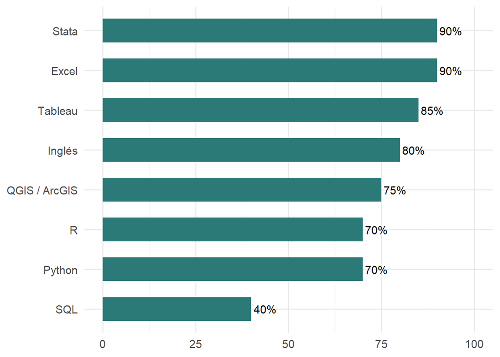

# Docencia

### 2025 - El estudio sociológico de la pobreza :debates y perspectivas contemporáneas

Lic. en Sociología | FaHCE - UNLP - Docente invitado

[Programa](https://www.memoria.fahce.unlp.edu.ar/programas/pp.13409/pp.13409.pdf)

### 2025 - Aportes para el Análisis Cuantitativo. Interpretación, usos y construcción de información estadística

Secretaría de Investigación | Universidad del Este

[Información](https://www.ude.edu.ar/noticias-ude/finalizo-el-seminario-sobre-analisis-cuantitativo-para-la-investigacion-en-ciencias-sociales/)

### 2025 - Demografía y Estadística Aplicadas a la Gestión del Riesgo

Lic. en Gestión de Riesgos | Instituto Universitario Juan Vucetich

### 2024 - Análisis de políticas públicas

Especialización en Políticas Públicas | UCALP

### 2024 - Estadísticas Socioeconómicas

Diplomatura Universitaria en Diseño y Producción de Estadísticas Locales.| FCE UNLP - IPAP

# Consultorías

### 2022 - Programa de desarrollo de las cadenas de valor en la localidad de Mercedes

Municipalidad de Mercedes | CFI-GESDCS

[Programa Mercedes Produce](http://biblioteca.cfi.org.ar/wp-content/uploads/sites/2/2024/10/mercedes-cfi.pdf)

### 2021 - Evaluación de resultados del Programa Hacemos Futuro

Prosecretaría de Políticas Sociales | UNLP

[Programa Hecemos Futuro](https://www.argentina.gob.ar/sites/default/files/informe_final_evaluacion_de_resultados_del_programa_hacemos_futuro.pdf)

# Investigación

### 2025 -Cuidados y reproducción social: estudios con familias migrantes en contextos de pobreza en el Gran La Plata (2025–2028).

CIMeCS/IdIHCS - UNLP | CONICET

[Propuesta](https://cyt.proyectos.unlp.edu.ar/projects/11-H1066)

### 2020 - Políticas públicas y gestión estatal en la provincia de Buenos Aires (2020–2028)

IdIHCS - UNLP | CONICET

[Propuesta](https://cyt.proyectos.unlp.edu.ar/projects/11-H1083)

### 2019 - Reformas y transformaciones estatales en la Provincia de Buenos Aires (2003-2020)

IdIHCS - UNLP | CONICET

[Propuesta](https://cyt.proyectos.unlp.edu.ar/projects/11-H902)

### 2019 - Medición de la pobreza multidimensional en la provincia de Buenos Aires

IELDE | Departamento de Análisis de las Estadísticas Sociales, DPE

[Propuesta](https://www.economicas.unsa.edu.ar/web/index.php/component/k2/item/119-medicion-de-la-pobreza-multidimensional-en-la-provincia-de-buenos-aires)

# Documentos de trabajo - DPE

### 2025 - Indicadores Socioeconómicos de General San Martín

Departamento de Análisis de las Estadísticas Sociales | DPE

[Informe](https://www.estadistica.ec.gba.gov.ar/dpe/images/INDICADORES_SOCIOECONOMICOS_SAN_MARTIN_2024.pdf)

### 2025 - Mercado de Trabajo. Tasas e Indicadores Socioeconómicos

Departamento de Análisis de las Estadísticas Sociales | DPE

[Informe](https://track-web-dpe.estadistica.ec.gba.gov.ar/uploads/3_T_2025_MERCADO_LABORAL_TASAS_E_INDICADORES_1_59e29662fc.pdf)

### 2025 - Incidencia de la pobreza y la indigencia

Departamento de Análisis de las Estadísticas Sociales | DPE

[Informe](https://track-web-dpe.estadistica.ec.gba.gov.ar/uploads/Incidencia_de_la_Pobreza_y_la_Indigencia_Total_6_aglomerados_PBA_1er_Semestre_2025_db419ca607.pdf)

### 2025 - Indicadores de Condiciones de Vida

Departamento de Análisis de las Estadísticas Sociales | DPE

[Informe](https://track-web-dpe.estadistica.ec.gba.gov.ar/uploads/Condiciones_de_Vida_Total_6_aglomerados_PBA_1er_Semestre_2025_26d36c71ea.pdf)

### 2025 - Distribución del Ingreso

Departamento de Análisis de las Estadísticas Sociales | DPE

[Informe](https://track-web-dpe.estadistica.ec.gba.gov.ar/uploads/Distribucion_del_Ingreso_3_T2025_N_0d110efe15.pdf)

### 2025 - EPH Total Urbano. Panorama 2020-2024

Departamento de Análisis de las Estadísticas Sociales | DPE

[Informe](https://track-web-dpe.estadistica.ec.gba.gov.ar/uploads/EAHU_INFORME_2019_2024_0dd810d6b3.pdf)

### 2024 - Encuesta Provincial de Consumo Energético para uso residencial 2023

Departamento de Análisis de las Estadísticas Sociales | DPE

[Informe](https://track-web-dpe.estadistica.ec.gba.gov.ar/uploads/Encuesta_Provincial_de_Consumo_Energetico_Residencial_2023_e137dc06e7.pdf)

### 2024 - Brechas de género en las microfinanzas. Provincia de Buenos Aires

Departamento de Análisis de las Estadísticas Sociales | DPE